# Practical 1: Processing Textual Data in R

Ayoub Bagheri

Introduction to Text Mining with R

# Introduction

Welcome to the first practical of the course “Introduction to Text Mining with R”.

In the practicals we will get hands-on experience with the materials in the lectures by programming in R and completing assignments. In this practical, we will work with different formats of text data, regular expressions and text visualizations.

The practicals always start with the packages we are going to use. Be sure to run these lines in your session to load their functions before you continue. If there are packages that you have not yet installed, first install them with `install.packages()`.

```r
library(dplyr)     # for data manipulation
library(plyr)      # for data manipulation
library(magrittr)  # for pipes
library(tidyverse) # for tidy data and pipes
library(ggplot2)   # for visualization
#library(xlsx)
#library(readxl)
library(openxlsx)  # for working with excel files
library(qdap)      # provides parsing tools for preparing transcript data; may need https://www.java.com/en/download/manual.jsp
library(wordcloud) # to create pretty word clouds
library(stringr)   # for working with regular expressions
```

Before starting the exercises, you need to set your working directory to your Practicals folder (or create a project folder). To this end, you can either create a project in RStudio and move the Rmd and data files to the project folder, or you can use the following line instead of creating a new project:

```r
# setwd("drivename:/folder1/folder2/r_tm/monday/Practicals/")
```

# Reading text data: Excel files

1. **Use the `read.xlsx` function from the `openxlsx` package to read the `blog-gender-dataset.xlsx` file. Alternatively, you can use the `read.xlsx` function from the `xlsx` package or the `read_excel` function from the `readxl` package.**

The dataset is already located in the practical folder. You can also find it online from [here](https://www.cs.uic.edu/~liub/FBS/sentiment-analysis.html#datasets)

```r
blog_gender_data <- read.xlsx("blog-gender-dataset.xlsx", 1)%>%
    select(blog, gender)
```

2. **Randomly sample 1000 of the blogs into a new variable and name it `blog_gender_1000`. Hint: use the `sample_n` function. Convert the object to a tibble.**

To learn more about the application of a function or feature in R, you can use one of the two following help commands:

```r
# help(your_function_name)
# ?your_function_name
```

```r
set.seed(123)
blog_gender_1000 <- sample_n(blog_gender_data, 1000)
#blog_gender_1000 <- slice_sample(blog_gender_data, n = 1000) #same as the line above
blog_gender_1000 <- as_tibble(blog_gender_1000)
```

3. **Use the `head`, `tail`, and `View` functions to check the dataset. What are the differences between these functions?**

```r
head(blog_gender_1000)
```

| blog | gender |
| --- | --- |
| Jane decided to attend the ward round meeting earlier this week. We had been to the planning meeting only a couple of weeks earlier. But of course, yet again, things change so quickly that there is a … | M |
| Sara and I got to the gym tonight for a nice workout at the BSC Westborough. I started off with a 2 mile run though I had intentions of running a bit further. I just didn't feel all that great and cou… | M |
| Miss D loves her Dumbo soft toy, It pretty much goes everywhere with us. If she’s tired or grumpy then she needs that elephant and bedtimes are a non-starter if he’s not around… I know she’ll grow out… | M |
| "By popular request in comment threads and emails, I'll be putting together a Saturday digest of election-oriented diaries from now until November. This project emerged from the Community Power! Elect… | M |
| The Ultimate Guide To Not Caring and Being Awesome\nToday’s guest post is from Diggy at Upgrade Reality where he talks about self improvement and personal growth. I had to post this guide, because it … | M |
| Whenever I feel the urge to play the older games, I always whip out Super Mario Bros.3 for the regular Nintendo. It is always fun. These games are the originals. I love playing any Super Mario game no… | M |

```r
tail(blog_gender_1000)
```

| blog | gender |
| --- | --- |
| \nFirstly, I get to go on tour with my brother again. We're biking across BC and to the West Coast. woot woot! and I was just talking to both my brothers over the phone, so that's made me even more ex… | F |
| I changed my watch. I wore a pair of shoes that had been ignored for long. I attended to my car repair personally. While driving to Jalsa I reprimanded a traffic offender. I sang along with the FM rad… | M |
| I am 13 and my boyfriend is 15, we have been dating a few weeks and I've only seen him twice because he lives an hour away. I have had boyfriends before, and only kissed and made out with one and we d… | F |
| Custom computer cases that look like spiders aren't generally the sort of thing that are available to public, but Lian Li's new PC-T1R case is one big exception to the rule, and it's now edged a bit c… | M |
| here im typing the testimonial for my sweet and lovely friend........what to say.... he looks like sharuk..... so why we call him as khan.... he is very nice to speak...... me and my friends really wo… | M |
| Website: www.livraineysmith.com Etsy: raineysmith.etsy.com , lovecraftian.etsy.com Brief Bio Printmaker Liv Rainey-Smith works with woodblocks to create richly colored prints. Her process incorporates… | F |

```r
# View(blog_gender_1000)
```

4. **`wordcloud` is a function from the `wordcloud` package which plots cool word clouds based on word frequencies in the given dataset. Use this function to plot the top 50 frequent words with minimum frequency of 10. Also use the exposition pipe operator `%$%`.**

The `%$%` pipe *exposes* the listed dimensions of a dataset, such that we can refer to them directly.

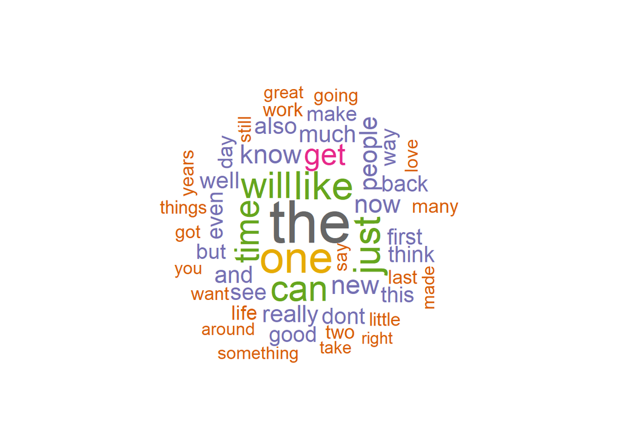

```r
set.seed(123)
blog_gender_1000 %$% wordcloud(blog, min.freq = 10, max.words = 50, random.order = FALSE,
                               colors = brewer.pal(8, "Dark2"))
```

# Reading text data: CSV files

5. **Use the `read.csv` function to read the `IMDB Dataset.csv` file. Convert the object into a tibble.**

IMDB dataset contains 50K movie reviews for natural language processing or Text analytics. You can also access the dataset from the [Kaggle website](https://www.kaggle.com/lakshmi25npathi/imdb-dataset-of-50k-movie-reviews).

```r
imdb_data <- read_csv("IMDB Dataset.csv")
imdb_data <- as_tibble(imdb_data)
```

6. **Use the `head` and `tail` functions to take a look at the dataset.**

```r
head(imdb_data)
```

| review | sentiment |
| --- | --- |
| One of the other reviewers has mentioned that after watching just 1 Oz episode you'll be hooked. They are right, as this is exactly what happened with me.The first thing that struck me about Oz was it… | positive |
| A wonderful little production. The filming technique is very unassuming- very old-time-BBC fashion and gives a comforting, and sometimes discomforting, sense of realism to the entire piece. The actors… | positive |
| I thought this was a wonderful way to spend time on a too hot summer weekend, sitting in the air conditioned theater and watching a light-hearted comedy. The plot is simplistic, but the dialogue is wi… | positive |
| Basically there's a family where a little boy (Jake) thinks there's a zombie in his closet & his parents are fighting all the time.This movie is slower than a soap opera... and suddenly, Jake decides … | negative |
| Petter Mattei's "Love in the Time of Money" is a visually stunning film to watch. Mr. Mattei offers us a vivid portrait about human relations. This is a movie that seems to be telling us what money, p… | positive |
| Probably my all-time favorite movie, a story of selflessness, sacrifice and dedication to a noble cause, but it's not preachy or boring. It just never gets old, despite my having seen it some 15 or mo… | positive |

```r
tail(imdb_data)
```

| review | sentiment |
| --- | --- |
| This is your typical junk comedy.There are almost no laughs. No genuine moments. No memorable lines. No scenes where you think to yourself, "that was clever". Nothing. The plot is embarrassingly bad. … | negative |
| I thought this movie did a down right good job. It wasn't as creative or original as the first, but who was expecting it to be. It was a whole lotta fun. the more i think about it the more i like it, … | positive |
| Bad plot, bad dialogue, bad acting, idiotic directing, the annoying porn groove soundtrack that ran continually over the overacted script, and a crappy copy of the VHS cannot be redeemed by consuming … | negative |
| I am a Catholic taught in parochial elementary schools by nuns, taught by Jesuit priests in high school & college. I am still a practicing Catholic but would not be considered a "good Catholic" in the… | negative |
| I'm going to have to disagree with the previous comment and side with Maltin on this one. This is a second rate, excessively vicious Western that creaks and groans trying to put across its central the… | negative |
| No one expects the Star Trek movies to be high art, but the fans do expect a movie that is as good as some of the best episodes. Unfortunately, this movie had a muddled, implausible plot that just lef… | negative |

7. **Randomly sample 500 of the reviews into a new variable and name it `imdb_500`. In your sample take care of having equal number of observations from positive and negative reviews. (250 each)**

```r
set.seed(123)
imdb_500 <- ddply(imdb_data, "sentiment", .fun = function(x) {sample_n(x, size = 250)})
#imdb_500 <- ddply(imdb_data, "sentiment", .fun = function(x) {slice_sample(x, n = 250)})
```

8. **Plot the word clouds of positive and negative reviews in your sample separately and compare the visualizations.**

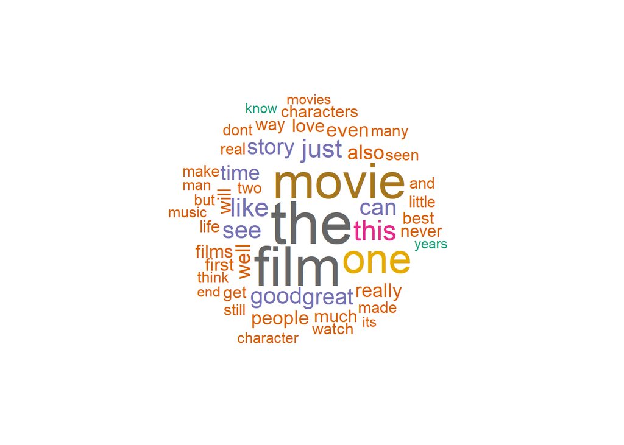

```r
set.seed(123)
imdb_500 %>%
  filter(sentiment == "positive") %$%
  wordcloud(review, min.freq = 20,
                       max.words = 50, random.order = FALSE,
                       colors = brewer.pal(8, "Dark2"))
```

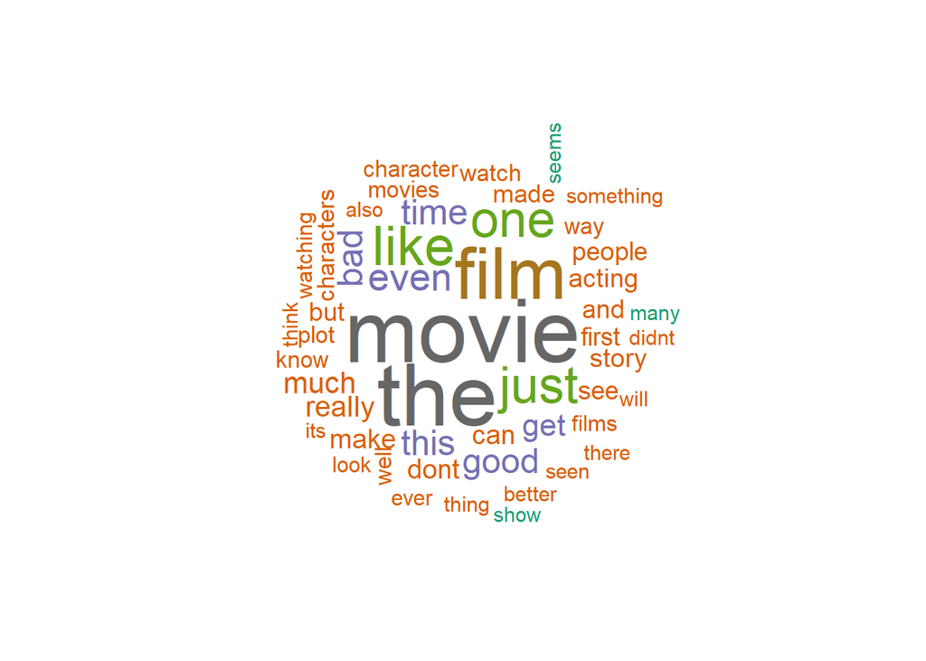

```r
set.seed(123)
imdb_500 %>%
  filter(sentiment == "negative") %$%
  wordcloud(review, min.freq = 20,
                       max.words = 50, random.order = FALSE,
                       colors = brewer.pal(8, "Dark2"))
```

9. **Use the `freq_terms` function from the `qdap` package and find the 30 top terms in each set of positive and negative reviews in `imdb_500`.**

```r
frequent_terms_pos <- imdb_500 %>%
  filter(sentiment == "positive") %$%
  freq_terms(review, top = 30)

frequent_terms_neg <- imdb_500 %>%
  filter(sentiment == "negative") %$%
  freq_terms(review, top = 30)
```

10. **Using `ggplot`, plot a barchart for each of the freqent terms dataframes.**

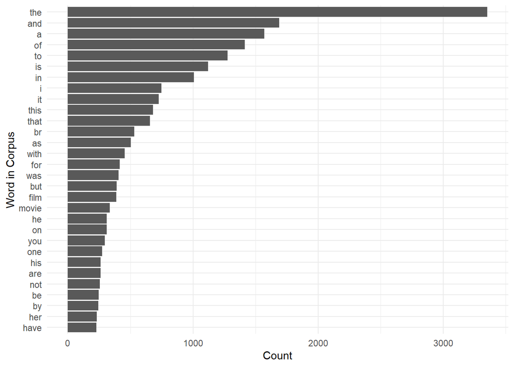

```r
ggplot(frequent_terms_pos, aes(x = reorder(WORD, FREQ), y = FREQ)) +
geom_bar(stat = "identity") +
coord_flip()                +
xlab("Word in Corpus")      +
ylab("Count")               +
theme_minimal()
```

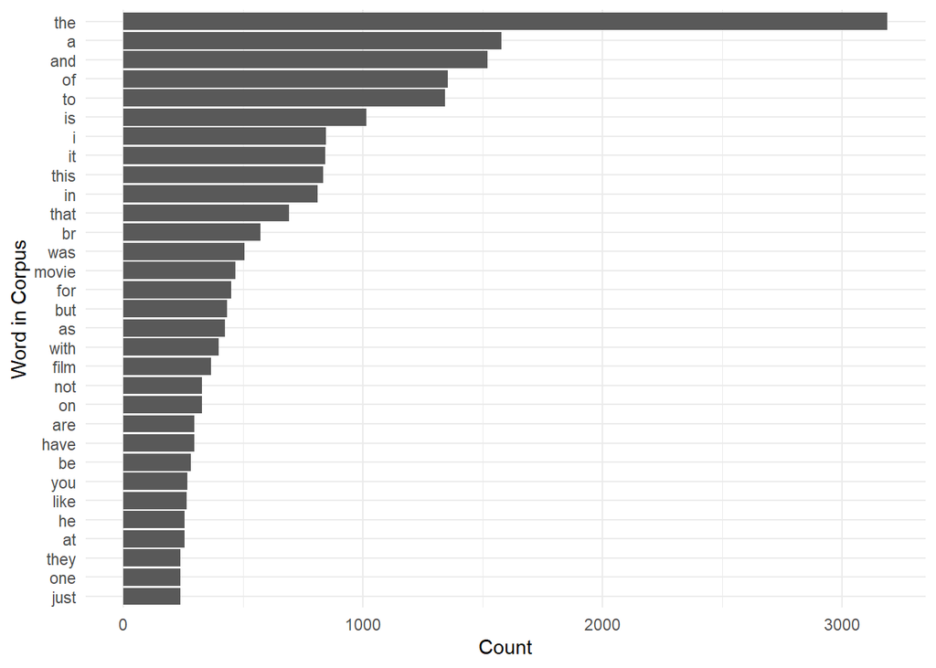

```r
ggplot(frequent_terms_neg, aes(x = reorder(WORD, FREQ), y = FREQ)) +
geom_bar(stat = "identity") +
coord_flip()                +
xlab("Word in Corpus")      +
ylab("Count")               +
theme_minimal()
```

Package `ggplot2` offers far greater flexibility in data visualization than the standard plotting devices in `R`. However, it has its own language, which allows you to easily expand graphs with additional commands. To make these expansions or layers clearly visible, it is advisable to use the plotting language conventions. All ggplot2 documentation can be found at http://docs.ggplot2.org/current/

# Reading text data: TXT files

11. **Use the `readLines` function to read data from the ‘computer.txt’ file.**

`Computer.txt` is an annotated dataset for the purpose of aspect-based sentiment analysis. You can find it from [here](https://www.cs.uic.edu/~liub/FBS/sentiment-analysis.html).

```r
computer_data <- readLines("computer.txt")
```

12. **Convert the data to a dataframe and name it `computer_531`.**

```r
computer_531 <- data.frame(computer_data)
```

As you may have noticed, here, we worked only with tibbles and dataframes. In addition to these, we will also use `VCorpus` data type.

13. **Use the `head` and `tail` functions to take a look at the dataset.**

```r
head(computer_531)
```

|  | computer_data |
| --- | --- |
| 1 | ## I purchased this monitor because of budgetary concerns . |
| 2 | inexpensive[+1][a] ## This item was the most inexpensive 17 inch monitor available to me at the time I made the purchase . |
| 3 | monitor[-1] ## My overall experience with this monitor was very poor . |
| 4 | screen[-1], picture quality[-1] ## When the screen was n't contracting or glitching the overall picture quality was poor to fair . |
| 5 | monitor[-1], picture quality[-1] ## I 've viewed numerous different monitor models since I 'm a college student and this particular monitor had as poor of picture quality as any I 've seen . |
| 6 | screen[-1] ## A week out of the box and I began to see slight contractions of the screen from time to time , growing more frequent each day . |

```r
tail(computer_531)
```

|  | computer_data |
| --- | --- |
| 526 | ## Eventually , I discovered that something was wrong with my display drivers and I simply wiped out windows and started over from scratch -LRB- had been meaning to do it anyway and I upgraded the HD … |
| 527 | ## After that , it worked like a champ . |
| 528 | ## No problems whatsoever . |
| 529 | incompatibility[-1] ## My only grips are the incompatibility with XP and the USB hub in the display . |
| 530 | ## This is a well know problem with the PCs and Apple does not seem to care . |
| 531 | ## Also , the only hard button controls you get are brightness and contrast . |

# Regular expressions

14. **Except `computer_531`, `imdb_500`, and `blog_gender_1000` remove the other files from the RStudio environment**

```r
# using regular expressions
rm(list = ls()[grep("data", ls())])
rm(list = ls()[grep("^fre", ls())])
gc() # "garbage collector" to free up memory of removed variables
```

```
##           used (Mb) gc trigger  (Mb) max used  (Mb)
## Ncells 1783038 95.3    3670955 196.1  3670955 196.1
## Vcells 3295401 25.2   16423800 125.4 16423767 125.4
```

```r
# or
# rm(blog_gender_data, computer_data, frequent_terms_pos, frequent_terms_neg, imdb_data)

# or use except files
# rm(list=setdiff(ls(), c("computer_531", "imdb_500", "blog_gender_1000")))
```

15. **Use regular expressions to find the number of reviews in `imdb_500` that contain words “Action” or “action”, “Comedy” or “comedy”, and “Drama” or “drama”. (each genre separately)**

```r
reviews_act <- grep("[Aa]ction", imdb_500$review)
reviews_com <- grep("[Cc]omedy", imdb_500$review)
reviews_dra <- grep("[Dd]rama", imdb_500$review)

genres    <- c("Action", "Comedy", "Drama")
nr_genres <- c(length(reviews_act), length(reviews_com), length(reviews_dra))

tibble(genres, nr_genres)
```

| genres | nr_genres |
| --- | --- |
| Action | 63 |
| Comedy | 47 |
| Drama | 37 |

16. **Use regular expressions to find the reviews in `imdb_500` that contain word “Comedy”. Hint: Set the `value` argument in the `grep` function equal to `TRUE`**

```r
grep("Comedy", imdb_500$review, value = TRUE)
```

```
## [1] "*****WARNING, MAY CONTAIN SPOILERS WHICH WILL BE MORE ENTERTAINING THAN THIS TRIPE.**** <br /><br />Heres some good advise to anyone living in the U.K. Whenever Channel 5 has an old 80's comedy on late at night, read a book instead. I am currently in the process of recovering from a seizure,…
## [2] "4 realz son my game iz mad tite yo I cant wait 2 get on dis show and roll up in da club n do it real 905 style wit mad models n bottles, son!<br /><br />No, I'm just kidding. This is a sad show, created by, and for the enjoyment of, sad men. Men who are so neutered by modern existence that t…
## [3] "Let me start by saying I don't recall laughing once during this comedy. From the opening scene, our protagonist Solo (Giovanni Ribisi) shows himself to be a self-absorbed, feeble, and neurotic loser completely unable to cope with the smallest responsibilities such as balancing a checkbook, k…
## [4] "You got to go and dig those holes. Holes only leaves troble, which makes a movie so good. Disney has done it again.Shia LaBeouf should be nominated for Best Actor for his performance as Stanley Yelnats. He has alredy won the Daytime Emmy for Best Actor in a Comedy Series (Even Stevens). Hole…
## [5] "After the success of the second instalment, Richard Curtis and Ben Elton decided that Blackadder should have a third appearance. This time instead of Tudor times or Elizabethan times, Edmund Blackadder (BAFTA nominated Rowan Atkinson) is living in the time of the French Revolution. Accompani…
## [6] "A very funny movie. Michael Douglas' \"do\" is worth watching this flick for if for no other reason. I'd like to see him do more of these low life roles. He was terrific, as were all the performers.<br /><br />The film struck me right off as an American Roshomon, only funnier and easier to w…
```

```r
# you can also use the returned index instead of setting value
```

`grep()` and the `grepl()` functions have some limitations. These functions tell you which strings in a character vector match a certain pattern but they don’t tell you where exactly the match occurs or what the match is for more complicated regular expression.

17. **Use the `regexpr` function to check if there is a fully capitalized word in each of the first 20 blogs in the `blog_gender_1000` data.**

```r
r <- regexpr('\\b[A-Z]+\\b', blog_gender_1000[1:20,]$blog) #\\b marks word boundary
r
```

```
##  [1]  -1  10   6  52 164  10  23 274 149 183   5  -1   9  74 514 314  11   1   1
## [20] 180
## attr(,"match.length")
##  [1] -1  1  1  1  1  1  1  1  1  1  1 -1  2  1  1  2  1  1  1  3
```

```r
regmatches(blog_gender_1000[1:20,]$blog, r)
```

```
##  [1] "I"   "D"   "I"   "I"   "I"   "I"   "U"   "I"   "T"   "I"   "UD"  "I"
## [13] "I"   "TI"  "I"   "I"   "I"   "UTI"
```

The regexpr() function gives you the (a) index into each string where the match begins and the (b) length of the match for that string.

The `str_extract` function from `stringr` is also a useful function for this purpose:

```r
str_extract(blog_gender_1000[1:20,]$blog, '\\b[A-Z]+\\b')
```

```
##  [1] NA    "I"   "D"   "I"   "I"   "I"   "I"   "U"   "I"   "T"   "I"   NA
## [13] "UD"  "I"   "I"   "TI"  "I"   "I"   "I"   "UTI"
```

18. **`regexpr` and `str_extract` only give you the first match of the string (reading left to right). On the other hand, `gregexpr` and `str_match_all` will give you all of the matches in a given string if there is more than one match. Use either of these functions to check if there are fully capitalized words in each of the first 10 blogs in the `blog_gender_1000` data.**

```r
r <- gregexpr('\\b[A-Z]+\\b', blog_gender_1000[1:10,]$blog)
regmatches(blog_gender_1000[1:10,]$blog, r)
## [[1]]
## character(0)
##
## [[2]]
## [1] "I"   "BSC" "I"   "I"   "I"   "I"   "I"   "I"
##
## [[3]]
## [1] "D"    "I"    "MUST" "I"    "D"    "I"
##
## [[4]]
##  [1] "I"         "I"         "A"         "A"         "A"         "DON"
##  [7] "T"         "WRITE"     "HEADLINES" "IN"        "ALL"       "CAPS"
## [13] "BREAKING"  "I"         "I"
##
## [[5]]
##  [1] "I"      "I"      "A"      "B"      "A"      "B"      "I"      "I"
##  [9] "I"      "WILL"   "YOU"    "I"      "I"      "I"      "I"      "I"
## [17] "I"      "I"      "I"      "I"      "I"      "I"      "I"      "I"
## [25] "I"      "I"      "I"      "I"      "I"      "I"      "I"      "HONEST"
##
## [[6]]
## [1] "I" "I" "I"
##
## [[7]]
##  [1] "I"    "M"    "NOT"  "AT"   "WORK" "I"    "I"    "I"    "I"    "I"
## [11] "I"    "WHY"  "I"    "I"    "I"
##
## [[8]]
## [1] "U"   "MBA" "MBA" "P"
##
## [[9]]
##   [1] "I"           "I"           "I"           "I"           "I"
##   [6] "I"           "I"           "I"           "I"           "A"
##  [11] "GROUP"       "OF"          "DIVERSE"     "CREATIVE"    "INSPIRING"
##  [16] "WOMEN"       "ME"          "I"           "I"           "I"
##  [21] "I"           "I"           "I"           "I"           "I"
##  [26] "I"           "I"           "TRUE"        "I"           "I"
##  [31] "I"           "I"           "I"           "I"           "I"
##  [36] "I"           "I"           "O"           "MOM"         "ME"
##  [41] "I"           "I"           "I"           "WAIT"        "FOR"
##  [46] "IT"          "THE"         "FATAL"       "BLUE"        "SCREEN"
##  [51] "ERROR"       "I"           "WTF"         "I"           "AND"
##  [56] "SYSTEM"      "HAS"         "EXPERIENCED" "A"           "FATAL"
##  [61] "DISC"        "ERROR"       "I"           "IT"          "I"
##  [66] "MORE"        "I"           "I"           "I"           "I"
##  [71] "BAD"         "I"           "O"           "I"           "I"
##  [76] "I"           "I"           "BORED"       "I"           "OUT"
##  [81] "BB"          "I"           "I"           "I"           "LOVING"
##  [86] "I"           "I"           "A"           "I"           "I"
##  [91] "I"           "EVERYTHANG"  "I"           "I"           "I"
##  [96] "EXCEPT"      "I"           "I"           "YES"         "I"
## [101] "I"           "I"           "GOLD"        "I"           "GOOOOOOD"
## [106] "LONG"        "I"           "LONG"        "I"           "I"
## [111] "S"           "O"           "S"           "I"           "NO"
## [116] "I"           "I"           "I"           "I"           "I"
## [121] "I"           "I"           "I"           "DVD"         "TV"
## [126] "NOTHING"     "I"           "I"           "I"           "TWO"
## [131] "I"           "I"           "LITTLE"      "MOST"        "A"
## [136] "KNOWING"     "BB"          "I"           "I"           "FINISHED"
## [141] "I"           "I"           "OFF"         "I"
##
## [[10]]
##  [1] "T"   "US"  "US"  "OK"  "I"   "I"   "I"   "I"   "I"   "I"   "I"   "USB"
## [13] "I"   "I"   "I"   "I"   "I"   "I"   "I"   "AMD" "I"   "TED"

# or
#str_match_all(blog_gender_1000[1:10,]$blog, '\\b[A-Z]+\\b')
```

19. **Now we want to process the `computer_531` data and separate aspects and sentiments for each record. First, use regular expression to extract the characters at the beginning of each line until `##`. Apply this only for the first 20 reviews in data. Use `str_extract` or `gsub` function.**

```r
str_extract(computer_531[1:20,], "[^#]*")
```

```
##  [1] ""                                  "inexpensive[+1][a] "
##  [3] "monitor[-1] "                      "screen[-1], picture quality[-1] "
##  [5] "monitor[-1], picture quality[-1] " "screen[-1] "
##  [7] "Display[-1] "                      "monitor[-1] "
##  [9] ""                                  ""
## [11] ""                                  ""
## [13] ""                                  "monitor[-1], colors[-1] "
## [15] ""                                  "size[+1] "
## [17] "computer[+1], quality[+1] "        ""
## [19] "keyboard[+1], color[+1] "          "speed[+1], memory[+1] "
```

```r
# gsub("[^##]*", "\\1", computer_531[1:20,])

gsub("(.?)(##.*)", "\\1", computer_531[1:20,])
```

```
##  [1] ""                                  "inexpensive[+1][a] "
##  [3] "monitor[-1] "                      "screen[-1], picture quality[-1] "
##  [5] "monitor[-1], picture quality[-1] " "screen[-1] "
##  [7] "Display[-1] "                      "monitor[-1] "
##  [9] ""                                  ""
## [11] ""                                  ""
## [13] ""                                  "monitor[-1], colors[-1] "
## [15] ""                                  "size[+1] "
## [17] "computer[+1], quality[+1] "        ""
## [19] "keyboard[+1], color[+1] "          "speed[+1], memory[+1] "
```

20. **Add two new columns to `computer_531` and name them aspect_sentiment and review. Fill the `aspect_sentiment` column for the dataframe with the command you found in the previous question. In the `review` column, only keep the review text for each line in the dataframe.**

```r
computer_531$aspect_sentiment <- gsub("(.?)(##.*)", "\\1", computer_531[,])
head(computer_531)
```

|  | computer_data | aspect_sentiment |
| --- | --- | --- |
| 1 | ## I purchased this monitor because of budgetary concerns . |  |
| 2 | inexpensive[+1][a] ## This item was the most inexpensive 17 inch monitor available to me at the time I made the purchase . | inexpensive[+1][a] |
| 3 | monitor[-1] ## My overall experience with this monitor was very poor . | monitor[-1] |
| 4 | screen[-1], picture quality[-1] ## When the screen was n't contracting or glitching the overall picture quality was poor to fair . | screen[-1], picture quality[-1] |
| 5 | monitor[-1], picture quality[-1] ## I 've viewed numerous different monitor models since I 'm a college student and this particular monitor had as poor of picture quality as any I 've seen . | monitor[-1], picture quality[-1] |
| 6 | screen[-1] ## A week out of the box and I began to see slight contractions of the screen from time to time , growing more frequent each day . | screen[-1] |

```r
## keep only reviews:

computer_531$review <- sub('(.*)(##?)', '', computer_531[,]$computer_data)
```

The difference is that sub only replaces the first occurrence of the pattern specified, whereas gsub does it for all occurrences (that is, it replaces globally). sub and gsub perform replacement of the first and all matches respectively.

21. **Now remove the sentiment scores from aspects. Add only the aspect to another column to `computer_531` and name it `aspects`.**

```r
computer_531$aspects <- gsub("\\[.+?\\]", "", computer_531$aspect_sentiment) #the \\ is used to escape [ and ]
head(computer_531)
```

|  | computer_data | aspect_sentiment | review | aspects |
| --- | --- | --- | --- | --- |
| 1 | ## I purchased this monitor because of budgetary concerns . |  | I purchased this monitor because of budgetary concerns . |  |
| 2 | inexpensive[+1][a] ## This item was the most inexpensive 17 inch monitor available to me at the time I made the purchase . | inexpensive[+1][a] | This item was the most inexpensive 17 inch monitor available to me at the time I made the purchase . | inexpensive |
| 3 | monitor[-1] ## My overall experience with this monitor was very poor . | monitor[-1] | My overall experience with this monitor was very poor . | monitor |
| 4 | screen[-1], picture quality[-1] ## When the screen was n't contracting or glitching the overall picture quality was poor to fair . | screen[-1], picture quality[-1] | When the screen was n't contracting or glitching the overall picture quality was poor to fair . | screen, picture quality |
| 5 | monitor[-1], picture quality[-1] ## I 've viewed numerous different monitor models since I 'm a college student and this particular monitor had as poor of picture quality as any I 've seen . | monitor[-1], picture quality[-1] | I 've viewed numerous different monitor models since I 'm a college student and this particular monitor had as poor of picture quality as any I 've seen . | monitor, picture quality |
| 6 | screen[-1] ## A week out of the box and I began to see slight contractions of the screen from time to time , growing more frequent each day . | screen[-1] | A week out of the box and I began to see slight contractions of the screen from time to time , growing more frequent each day . | screen |

```r
# computer_531 <- computer_531 %>%
#  mutate(aspects = gsub("\\[.+?\\]", "", computer_531$aspect_sentiment))


# only for +1 and -1
# gsub("\\[(.+?)1\\]", "", "a yes[+1][a]")
# gsub("\\[(\\+|-)1\\]", "", "a yes[+1][a]")
```

Using `unlist(strsplit(string, ","))` gives you back a vector of separated aspects.

22. **Create a new column `sentiment` with the values `positive`, `negative` and `neutral`. Set a value `neutral` if there is no aspect in the corresponding column or the sum of scores is equal to zero. Save the resulting object as a csv. file and name it `computer_531.csv`**

```r
computer_531 <- computer_531 %>%
  mutate(sentiment_score = 0)

for(i in 1:nrow(computer_531)){
  score_list <- str_extract_all(computer_531[i,]$aspect_sentiment, "-?\\d+") #? matches previous element (-) 0 or more times
    if(length(score_list[[1]]) != 0){ # we changed 1 to lengths(score_list) to have the last number found by re, because we have 17 and 19 in the score list
    computer_531[i,]$sentiment_score <- sum(as.numeric(as.character(unlist(score_list)[[lengths(score_list)]])))
  }
}
```

```r
computer_531 <- computer_531 %>%
  mutate(sentiment = "neutral")

for(i in 1:nrow(computer_531)){
  if (as.numeric(computer_531[i,]$sentiment_score) < 0) {
      computer_531[i,]$sentiment <- "negative"
    }
    else if(as.numeric(computer_531[i,]$sentiment_score) > 0) {
      computer_531[i,]$sentiment <- "positive"
    }
}

head(computer_531)
```

|  | computer_data | aspect_sentiment | review | aspects | sentiment_score | sentiment |
| --- | --- | --- | --- | --- | --- | --- |
| 1 | ## I purchased this monitor because of budgetary concerns . |  | I purchased this monitor because of budgetary concerns . |  | 0 | neutral |
| 2 | inexpensive[+1][a] ## This item was the most inexpensive 17 inch monitor available to me at the time I made the purchase . | inexpensive[+1][a] | This item was the most inexpensive 17 inch monitor available to me at the time I made the purchase . | inexpensive | 1 | positive |
| 3 | monitor[-1] ## My overall experience with this monitor was very poor . | monitor[-1] | My overall experience with this monitor was very poor . | monitor | -1 | negative |
| 4 | screen[-1], picture quality[-1] ## When the screen was n't contracting or glitching the overall picture quality was poor to fair . | screen[-1], picture quality[-1] | When the screen was n't contracting or glitching the overall picture quality was poor to fair . | screen, picture quality | -1 | negative |
| 5 | monitor[-1], picture quality[-1] ## I 've viewed numerous different monitor models since I 'm a college student and this particular monitor had as poor of picture quality as any I 've seen . | monitor[-1], picture quality[-1] | I 've viewed numerous different monitor models since I 'm a college student and this particular monitor had as poor of picture quality as any I 've seen . | monitor, picture quality | -1 | negative |
| 6 | screen[-1] ## A week out of the box and I began to see slight contractions of the screen from time to time , growing more frequent each day . | screen[-1] | A week out of the box and I began to see slight contractions of the screen from time to time , growing more frequent each day . | screen | -1 | negative |

```r
write_csv(computer_531, "computer_531.csv")
```

# Summary

- Text mining packages
- Different text file formats

The primary R functions for dealing with regular expressions are:

- `grep()`, `grepl()`: Search for matches of a regular expression/pattern in a character vector
- `regexpr()`, `gregexpr()`: Search a character vector for regular expression matches and return the indices where the match begins; useful in conjunction with `regmatches()`
- `sub()`, `gsub()`: Search a character vector for regular expression matches and replace that match with another string
- The `stringr` package provides a series of functions implementing much of the regular expression functionality in R but with a more consistent and rationalized interface.

End of Practical